# lab12

Austin Melendez

2026-05-11

```r
#install.packages("ISLR2")
#install.packages("dendextend")

library(ISLR2)
library(dendextend)
```

Section 12.6: Exercises 9, 13

## Exercise 9

Consider the `USArrests data`. We will now perform hierarchical clustering on the states.

```r
# Load data
data("USArrests")
```

### (a) Using hierarchial cluster with complete linkage and Euclidean distance, cluster the states.

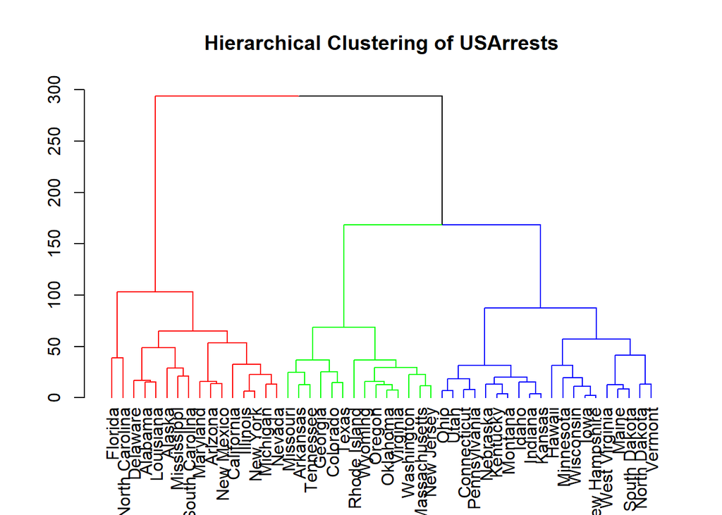

```r
# Compute Euclidean distance matrix
distances <- dist(USArrests)

# Hierarchical clustering using complete linkage
hc.complete <- hclust(distances, method = "complete")

# Convert to dendrogram and color clusters
dend.complete <- as.dendrogram(hc.complete)
dend.complete <- color_branches(dend.complete, k = 3)
# Plot dendrogram
plot(dend.complete,
     main = "Hierarchical Clustering of USArrests",
     xlab = "",
     sub = "")
```

### (b) Cut the dendrogram at a height that results in three distinct clusters. Which states belong to which clusters?

```r
# Cut tree into 3 clusters
clusters <- cutree(hc.complete, 3)

# Display states in each cluster
split(names(clusters), clusters)
```

```
## $`1`
##  [1] "Alabama"        "Alaska"         "Arizona"        "California"
##  [5] "Delaware"       "Florida"        "Illinois"       "Louisiana"
##  [9] "Maryland"       "Michigan"       "Mississippi"    "Nevada"
## [13] "New Mexico"     "New York"       "North Carolina" "South Carolina"
##
## $`2`
##  [1] "Arkansas"      "Colorado"      "Georgia"       "Massachusetts"
##  [5] "Missouri"      "New Jersey"    "Oklahoma"      "Oregon"
##  [9] "Rhode Island"  "Tennessee"     "Texas"         "Virginia"
## [13] "Washington"    "Wyoming"
##
## $`3`
##  [1] "Connecticut"   "Hawaii"        "Idaho"         "Indiana"
##  [5] "Iowa"          "Kansas"        "Kentucky"      "Maine"
##  [9] "Minnesota"     "Montana"       "Nebraska"      "New Hampshire"
## [13] "North Dakota"  "Ohio"          "Pennsylvania"  "South Dakota"
## [17] "Utah"          "Vermont"       "West Virginia" "Wisconsin"
```

### (c) Hierarchically cluster the states using complete linkage and Euclidean distance, after scaling the variables to have standard deviation one.

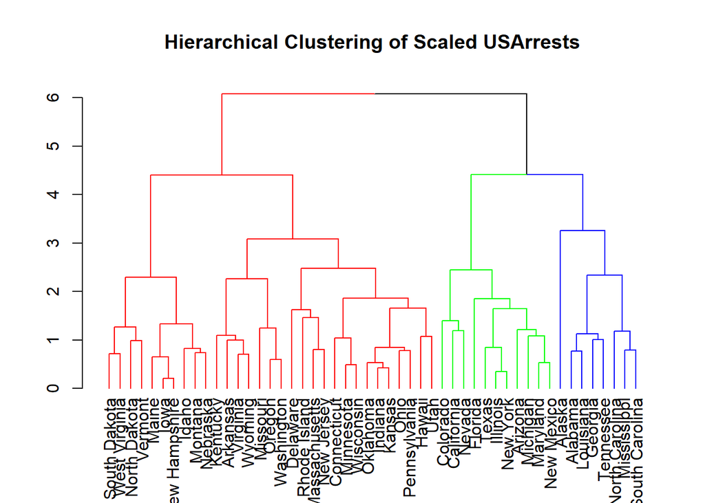

```r
# Scale variables
scaled.data <- scale(USArrests)

# Compute distances on scaled data
dist.scaled <- dist(scaled.data)

# Hierarchical clustering
hc.scaled <- hclust(dist.scaled, method = "complete")

# Convert to dendrogram and color clusters
dend.scaled <- as.dendrogram(hc.scaled)
dend.scaled <- color_branches(dend.scaled, k = 3)
# Plot dendrogram
plot(dend.scaled,
     main = "Hierarchical Clustering of Scaled USArrests",
     xlab = "",
     sub = "")
```

### (d) What effect does scaling the variables have on the hierarchical clustering obtained? In your opinion, should the variables be scaled before the interobservation dissimilarities are computed?

## Exercise 13

On the book website, www.statlearning.com, there is a gene expression data set `Ch12Ex13.csv` that consists of 40 tissue samples with measurements on 1,000 genes. The first 20 samples are from healthy patients, while the second 20 are from a diseased group.

### (a) Load in the data using read.csv(). You will need to select header = F.

```r
# Load gene expression data
gene.data <- read.csv("Ch12Ex13.csv", header = FALSE)

# Check dimensions
dim(gene.data)
```

```
## [1] 1000   40
```

The dataset contains:

- 40 tissue samples
- 1,000 gene expression measurements

The first 20 samples are healthy patients and the next 20 are diseased patients.

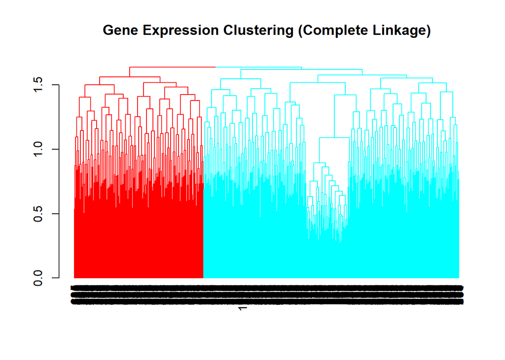

```r
# Transpose so rows = samples
gene.data.t <- t(gene.data)

# Correlation-based distance
gene.cor <- cor(gene.data.t)

gene.dist <- as.dist(1 - gene.cor)

# Complete linkage clustering
hc.genes.complete <- hclust(gene.dist, method = "complete")


# Convert to dendrogram and color clusters
dend.genes.complete <- as.dendrogram(hc.genes.complete)
dend.genes.complete <- color_branches(dend.genes.complete, k = 2)
# Plot dendrogram
plot(dend.genes.complete,
     main = "Gene Expression Clustering (Complete Linkage)",
     xlab = "",
     sub = "")
```

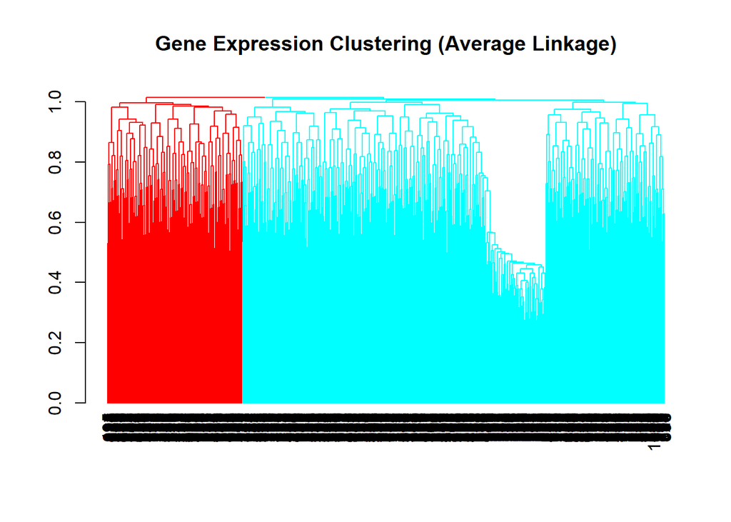

```r
# Average linkage
hc.genes.average <- hclust(gene.dist, method = "average")

# Convert to dendrogram and color clusters
dend.genes.average <- as.dendrogram(hc.genes.average)
dend.genes.average <- color_branches(dend.genes.average, k = 2)
plot(dend.genes.average,
     main = "Gene Expression Clustering (Average Linkage)",
     xlab = "",
     sub = "")
```

### (c) Your collaborator wants to know which genes differ the most across the two groups. Suggest a way to answer this question, and apply it here.

A simple approach is to compare the mean expression level of each gene between healthy and diseased samples.

```r
# Healthy and diseased groups
healthy <- gene.data[, 1:20]
disease <- gene.data[, 21:40]

# Compute difference in mean expression
mean.diff <- abs(rowMeans(healthy) - rowMeans(disease))

# Find genes with largest differences
top.genes <- order(mean.diff, decreasing = TRUE)[1:10]

# Display top genes
print("Top genes with largest differences:")
```

```
## [1] "Top genes with largest differences:"
```

```r
top.genes
```

```
##  [1] 600 584 549 540 502 568 582 565 562 554
```

```r
# Corresponding differences
print("Corresponding differences:")
```

```
## [1] "Corresponding differences:"
```

```r
mean.diff[top.genes]
```

```
##  [1] 2.747577 2.601985 2.550757 2.545174 2.544461 2.519418 2.496084 2.470820
##  [9] 2.465549 2.436718
```